# Lab 3 - Checkpoint 3

Arnaldo Gualberto

9 de maio de 2017

O objetivo do checkpoint 3 do Lab 3 é realizar novamente a clusterização de algum conjunto de dados, porém desta vez o foco é a visualização dos dados através de técnicas de redução de dimensionalidade.

Para esse checkpoint, foram utilizados dados quantitativos que a CAPES utiliza na avaliação dos programas de pós-graduação em Ciência da Computação segundo o Comitê de Avaliação. Os dados foram coletados da Plataforma Sucupira, e incluem quantificações da produção de artigos, dissertações e teses nos últimos 4 anos para os diferentes PPGs.

# 0. Imports and Settings

```r
library(broom)
library(cluster)
library(dplyr, warn.conflicts = FALSE)
library(GGally, warn.conflicts = FALSE)
library(ggdendro)
library(ggplot2)
library(ggfortify)
library(highcharter, quietly = TRUE)
library(knitr)
library(readr)
library(tibble)
library(tidyr)
require(Rtsne, quietly = TRUE)
source('multiplot.R')

# Coloca todos os titulos dos gráficos centralizados
theme_update(plot.title = element_text(hjust=0.5))
```

# 1. Análise Descritiva {analise}

Primeiramente, vou carregar os dados e ter uma noção do seus valores:

```r
dados_all <- read_csv("data/capes-cacc.csv")
glimpse(dados_all)
```

```
## Observations: 75
## Variables: 31
## $ Instituição                <chr> "UNIVERSIDADE FEDERAL DO AMAZONAS",...
## $ Programa                   <chr> "INFORMÁTICA (12001015012P2)", "CIÊ...
## $ Nível                      <int> 5, 4, 3, 3, 3, 5, 4, 3, 3, 3, 5, 3,...
## $ Sigla                      <chr> "UFAM", "UFPA", "UFMA", "UEMA", "FU...
## $ Tem doutorado              <chr> "Sim", "Sim", "Não", "Não", "Não", ...
## $ Docentes colaboradores     <dbl> 0.25, 5.50, 3.00, 6.25, 1.75, 2.00,...
## $ Docentes permanentes       <dbl> 24.75, 14.00, 10.00, 14.00, 9.50, 2...
## $ Docentes visitantes        <dbl> 0.00, 0.00, 0.00, 0.00, 0.00, 0.75,...
## $ Resumos em conf            <int> 20, 23, 15, 5, 4, 10, 6, 136, 0, 24...
## $ Resumos expandidos em conf <int> 25, 24, 7, 10, 1, 68, 9, 13, 4, 6, ...
## $ Artigos em conf            <int> 390, 284, 115, 73, 150, 269, 179, 0...
## $ Dissertacoes               <int> 108, 77, 50, 25, 31, 75, 60, 129, 4...
## $ Teses                      <int> 14, NA, NA, NA, NA, 24, 5, NA, NA, ...
```

[output cut: 18 more lines]

Logo, além dessas duas variáveis, para essa análise, também considerarei outras seis variáveis:

- **nível**: nível da pós-graduação da instituição definido pela CAPES (de 3 a 7);
- **colaboradores**: média da quantidade de docentes colaboradores por ano ao longo do período considerado pela CAPES para avaliação;
- **permanentes**: média da quantidade de docentes permanentes da instituição por ano ao longo do mesmo período;
- **artigos_conf**: quantidade de artigos publicados em Conferências;
- **dissertacoes**: quantidade de dissertações de Mestrado;
- **teses**: quantidade de teses de Doutorado;

Para fins de visualização, também vou armazenar o nome da instituição juntamente com sua sigla correspondente.

```r
dados <- dados_all %>%
  replace(is.na(.), 0) %>%
  mutate(instituicao = sprintf("%s (%s)", Instituição, Sigla)) %>%
  mutate(periodicos_restrito = periodicos_A1 + periodicos_A2 + periodicos_B1) %>%
  mutate(periodicos_qualis = periodicos_B1 + periodicos_B2 + periodicos_B3 + periodicos_B4 + periodicos_B5) %>%
  select(instituicao,
         nivel = Nível,
         colaboradores = `Docentes colaboradores`,
         permanentes = `Docentes permanentes`,
         artigos_conf = `Artigos em conf`,
         dissertacoes = Dissertacoes,
         teses = Teses,
         periodicos_restrito,
         periodicos_qualis)

dados %>% head() %>% kable()
```

| instituicao | nivel | colaboradores | permanentes | artigos_conf | dissertacoes | teses | periodicos_restrito | periodicos_qualis |
| --- | --- | --- | --- | --- | --- | --- | --- | --- |
| UNIVERSIDADE FEDERAL DO AMAZONAS (UFAM) | 5 | 0.25 | 24.75 | 390 | 108 | 14 | 53 | 33 |
| UNIVERSIDADE FEDERAL DO PARÁ (UFPA) | 4 | 5.50 | 14.00 | 284 | 77 | 0 | 78 | 86 |
| UNIVERSIDADE FEDERAL DO MARANHÃO (UFMA) | 3 | 3.00 | 10.00 | 115 | 50 | 0 | 23 | 19 |
| UNIVERSIDADE ESTADUAL DO MARANHÃO (UEMA) | 3 | 6.25 | 14.00 | 73 | 25 | 0 | 5 | 18 |
| FUNDAÇÃO UNIVERSIDADE FEDERAL DO PIAUÍ (FUFPI) | 3 | 1.75 | 9.50 | 150 | 31 | 0 | 17 | 24 |
| UNIVERSIDADE FEDERAL DO CEARÁ (UFC) | 5 | 2.00 | 20.75 | 269 | 75 | 24 | 79 | 46 |

Vamos começar analisando o sumário dos dados:

```r
dados %>%
  select(-instituicao) %>%
  summary() %>%
  kable()
```

|  | nivel | colaboradores | permanentes | artigos_conf | dissertacoes | teses | periodicos_restrito | periodicos_qualis |
| --- | --- | --- | --- | --- | --- | --- | --- | --- |
|  | Min. :3.000 | Min. : 0.000 | Min. : 3.00 | Min. : 0.0 | Min. : 0.00 | Min. : 0.00 | Min. : 0.00 | Min. : 1.00 |
|  | 1st Qu.:3.000 | 1st Qu.: 1.125 | 1st Qu.:11.00 | 1st Qu.:121.5 | 1st Qu.: 35.50 | 1st Qu.: 0.00 | 1st Qu.: 17.50 | 1st Qu.: 18.50 |
|  | Median :3.000 | Median : 3.000 | Median :16.00 | Median :187.0 | Median : 56.00 | Median : 0.00 | Median : 40.00 | Median : 32.00 |
|  | Mean :3.813 | Mean : 3.990 | Mean :20.22 | Mean :239.6 | Mean : 73.77 | Mean : 14.56 | Mean : 56.87 | Mean : 42.39 |
|  | 3rd Qu.:4.000 | 3rd Qu.: 5.625 | 3rd Qu.:25.50 | 3rd Qu.:293.5 | 3rd Qu.:102.50 | 3rd Qu.: 14.00 | 3rd Qu.: 66.00 | 3rd Qu.: 53.00 |
|  | Max. :7.000 | Max. :22.250 | Max. :67.25 | Max. :959.0 | Max. :433.00 | Max. :152.00 | Max. :355.00 | Max. :274.00 |

O sumário dos dados apresentam informações interessantes:

- **Há uma instituição que publicou quase 1000 artigos em conferências** (vamos saber qual é mais a frente);
- Em média, **14 Doutores são formados no período de avaliação da CAPES**, aproximadamente.
- **Mais artigos são publicados em periódicos com Qualis restrito do que nos demais Qualis**, tanto na média quanto no total;

Também é importante saber o desvio-padrão dessas variáveis:

```r
dados %>%
  summarise(sd(colaboradores), sd(permanentes), sd(artigos_conf), sd(dissertacoes), sd(teses), sd(periodicos_qualis), sd(periodicos_restrito)) %>%
  kable()
```

| sd(colaboradores) | sd(permanentes) | sd(artigos_conf) | sd(dissertacoes) | sd(teses) | sd(periodicos_qualis) | sd(periodicos_restrito) |
| --- | --- | --- | --- | --- | --- | --- |
| 3.967443 | 12.35931 | 183.73 | 63.57281 | 30.65688 | 39.78961 | 64.96846 |

Podemos ver que *artigos em conferência* apresentam o maior desvio-padrão, seguido por *periódicos no Qualis restrito* e *dissertações*, respectivamente.

Vamos agora analisar a distribuição das variáveis individualmente e aos pares:

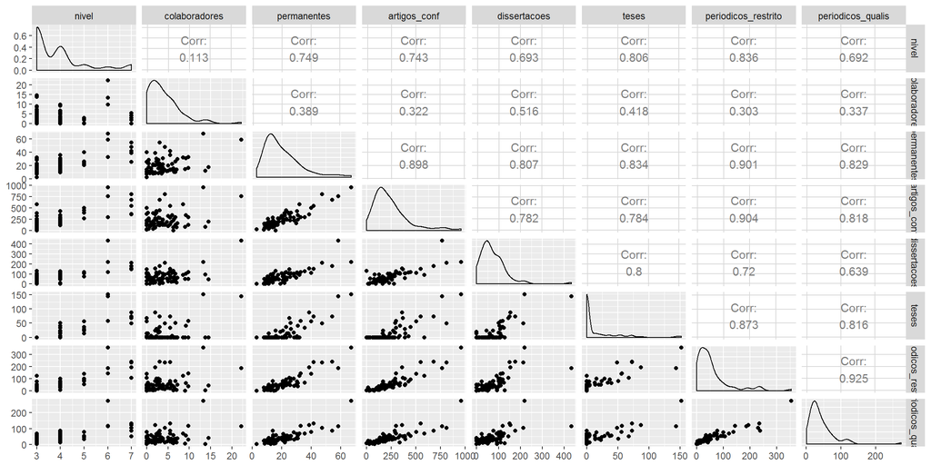

```r
dados %>%
  select(-instituicao) %>%
  ggpairs()
```

Ao analisar as variáveis de forma individual (diagonal principal), podemos ver que **praticamente todas as variáveis apresentam uma distribuição à esquerda com cauda longa à direita**. É importante destacar que a variável *nível* apresenta uma distribuição bimodal, devido ao fato de existirem mais programas de pós-graduação com níveis mais baixos (3 e 4).

Por outro lado, quando analisamos as variáveis aos pares, podemos ver que existem bastante correlações fortes (> 0.7) entre as variáveis. **A maior correlação é observada entre a quantidade de periódicos publicados no Qualis restrito e nos demais Qualis (0.925), ou seja, quanto mais se publica periódicos em eventos com Qualis restrito, mais se publica nos demais Qualis**. Obviamente, isso não representa uma causalidade, mas, de certa forma, é um comportamento esperado. **Também pode-se observar forte correlação entre a quantidade artigos publicados em periódicos com Qualis restrito e docentes permanentes (0.901) e artigos publicados em conferências (0.904)**.

Agora, quero fazer algumas visualizações. Primeiramente, quero analisar a distribuição dos níveis dos programas de pós-graduação do país:

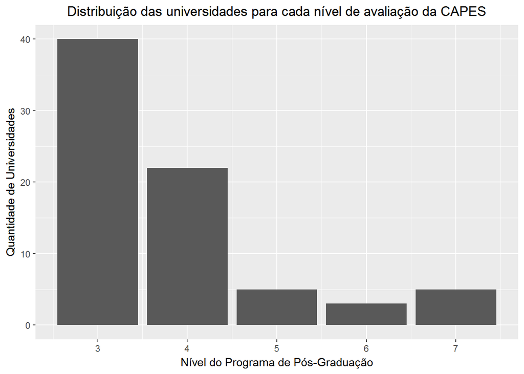

```r
dados %>%
  ggplot(aes(x = nivel)) +
  geom_bar() +
  ggtitle("Distribuição das universidades para cada nível de avaliação da CAPES") +
  labs(x = "Nível do Programa de Pós-Graduação", y = "Quantidade de Universidades")
```

Como visto anteriormente, **a maior parte dos programas de pós-graduação apresentam os níveis 3 e 4**. Há apenas 5 programas com nível 5. **É interessante observar que há mais programas de nível 7 do que 6 (5 contra 3, respectivamente)**.

Vamos analisar quais são as instituições que mais produzem dissertações de Mestrado:

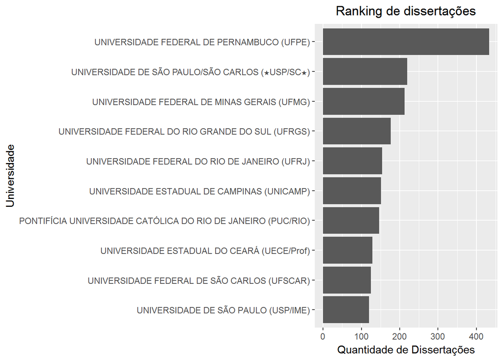

```r
dados %>%
  top_n(10, dissertacoes) %>%
  ggplot(aes(x = reorder(instituicao, dissertacoes), y = dissertacoes)) +
  geom_bar(stat = "identity") +
  coord_flip() +
  ggtitle("Ranking de dissertações") +
  labs(x = "Universidade", y = "Quantidade de Dissertações")
```

E qual será a universidade que mais produz teses de Doutorado?

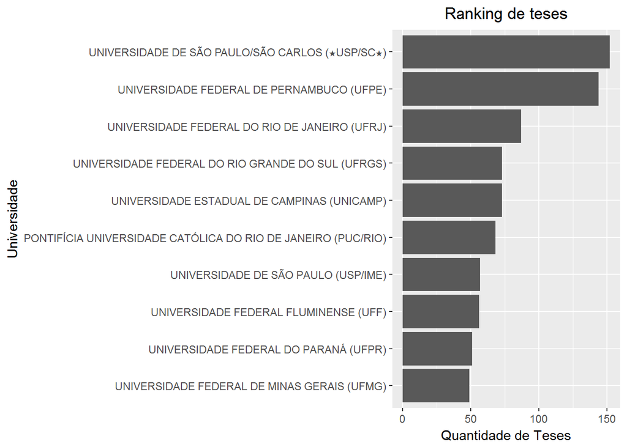

```r
dados %>%
  top_n(10, teses) %>%
  ggplot(aes(x = reorder(instituicao, teses), y = teses)) +
  geom_bar(stat = "identity") +
  coord_flip() +
  ggtitle("Ranking de teses") +
  labs(x = "Universidade", y = "Quantidade de Teses")
```

Nesse caso, ocorre o inverso, com a USP (São Carlos) à frente da UFPE. Porém, a quantidade de teses produzidas é bem mais parecida entre as duas universidades.

Qual a universidade que mais publica artigos em conferência?

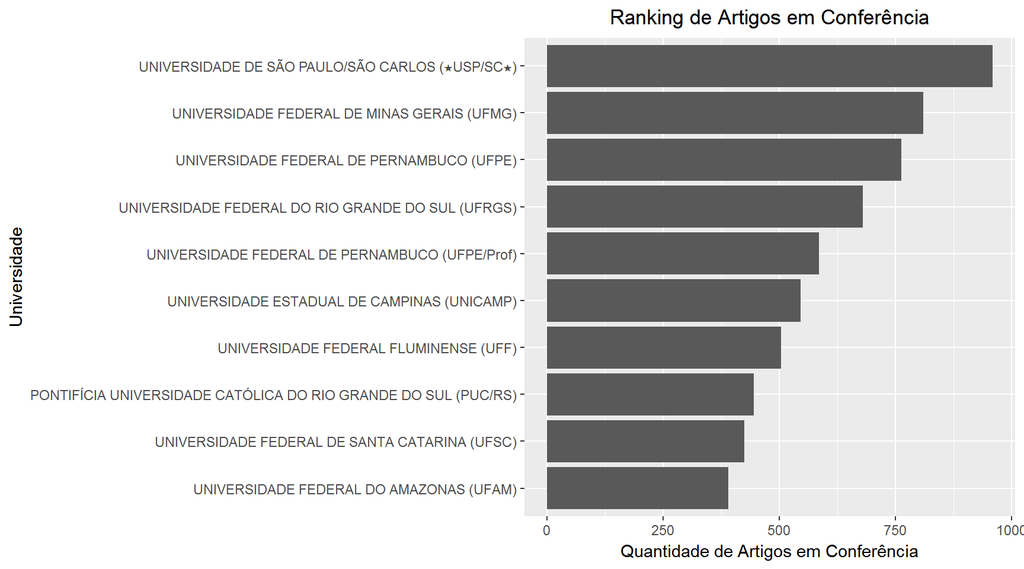

```r
dados %>%
  top_n(10, artigos_conf) %>%
  ggplot(aes(x = reorder(instituicao, artigos_conf), y = artigos_conf)) +
  geom_bar(stat = "identity") +
  coord_flip() +
  ggtitle("Ranking de Artigos em Conferência") +
  labs(x = "Universidade", y = "Quantidade de Artigos em Conferência")
```

De forma individual, **a USP de São Carlos é a universidade responsável pelo maior número de publicações em conferências**, seguida pela UFMG.

Quero agora saber a respeito das publicações em periódicos. Primeiramente, quero analisar as publicações dos periódicos fora do Qualis restrito (B2 a B5):

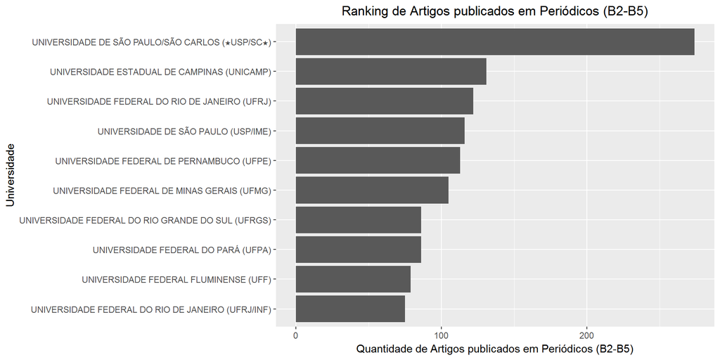

```r
dados %>%
  top_n(10, periodicos_qualis) %>%
  ggplot(aes(x = reorder(instituicao, periodicos_qualis), y = periodicos_qualis)) +
  geom_bar(stat = "identity") +
  coord_flip() +
  ggtitle("Ranking de Artigos publicados em Periódicos (B2-B5)") +
  labs(x = "Universidade", y = "Quantidade de Artigos publicados em Periódicos (B2-B5)")
```

Novamente, **a USP (São Carlos) lidera o ranking**, com aproximadamente o dobro da segunda colocada, a UNICAMP.

Por fim, quero fazer a mesma análise, porém para os artigos publicados em periódicos no Qualis restrito:

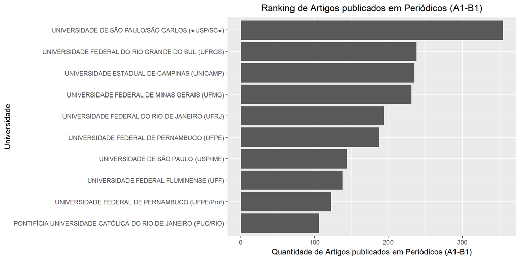

```r
dados %>%
  top_n(10, periodicos_restrito) %>%
  ggplot(aes(x = reorder(instituicao, periodicos_restrito), y = periodicos_restrito)) +
  geom_bar(stat = "identity") +
  coord_flip() +
  ggtitle("Ranking de Artigos publicados em Periódicos (A1-B1)") +
  labs(x = "Universidade", y = "Quantidade de Artigos publicados em Periódicos (A1-B1)")
```

Mais uma vez, **a USP de São Carlos encabeça o ranking, seguido pela UFRGS**.

É válido destacar que, de maneira geral, algumas das universidades mostradas nos gráficos acima aparecem em praticamente todos os gráficos. Talvez isso indique algum grupo que vamos encontrar no agrupamento que iremos realizar.

Para finalizar a análise descritiva, quero analisar a disposição das variáveis de forma individual:

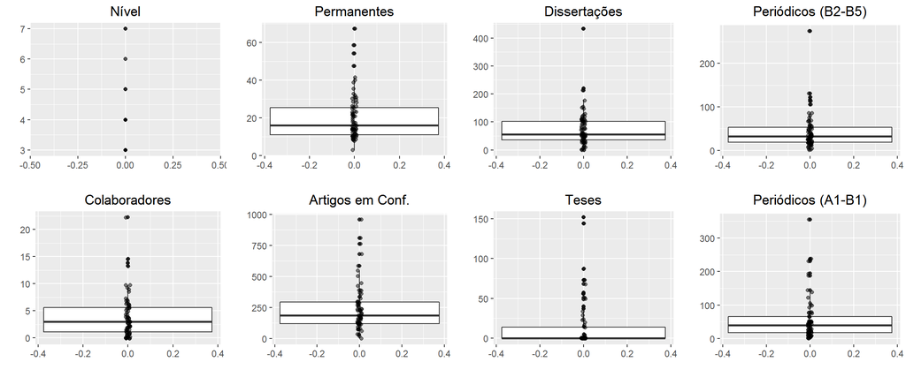

```r
plot_nivel <- dados %>%
  ggplot(aes(x = 0, y = nivel)) +
  geom_point(alpha = 0.3) +
  ggtitle("Nível") +
  labs(x="", y="")

plot_colaboradores <- dados %>%
  ggplot(aes(x = 0, y = colaboradores)) +
  geom_boxplot() +
  geom_point(alpha = 0.5, position = position_jitter(width = 0.01))  +
  ggtitle("Colaboradores") +
  labs(x="", y="")

plot_permanentes <- dados %>%
  ggplot(aes(x = 0, y = permanentes)) +
  geom_boxplot() +
  geom_point(alpha = 0.5, position = position_jitter(width = 0.01))  +
  ggtitle("Permanentes") +
  labs(x="", y="")

plot_artigos_conf <- dados %>%
  ggplot(aes(x = 0, y = artigos_conf)) +
  geom_boxplot() +
  geom_point(alpha = 0.5, position = position_jitter(width = 0.01))  +
  ggtitle("Artigos em Conf.") +
  labs(x="", y="")

plot_dissertacoes <- dados %>%
  ggplot(aes(x = 0, y = dissertacoes)) +
  geom_boxplot() +
  geom_point(alpha = 0.5, position = position_jitter(width = 0.01))  +
  ggtitle("Dissertações") +
  labs(x="", y="")

plot_teses <- dados %>%
  ggplot(aes(x = 0, y = teses)) +
  geom_boxplot() +
  geom_point(alpha = 0.5, position = position_jitter(width = 0.01))  +
  ggtitle("Teses") +
  labs(x="", y="")

plot_per_qualis <- dados %>%
  ggplot(aes(x = 0, y = periodicos_qualis)) +
  geom_boxplot() +
  geom_point(alpha = 0.5, position = position_jitter(width = 0.01))  +
  ggtitle("Periódicos (B2-B5)") +
  labs(x="", y="")

plot_per_restrito <- dados %>%
  ggplot(aes(x = 0, y = periodicos_restrito)) +
  geom_boxplot() +
  geom_point(alpha = 0.5, position = position_jitter(width = 0.01))  +
  ggtitle("Periódicos (A1-B1)") +
  labs(x="", y="")

multiplot(plot_nivel, plot_colaboradores, plot_permanentes, plot_artigos_conf, plot_dissertacoes, plot_teses, plot_per_qualis, plot_per_restrito, cols = 4)
```

Pelo gráfico acima, conseguimos confirmar que as variáveis se concentram na parte inferior do gráfico, como visto no gráfico de pares. Eu também arriscaria dizer que existem de 3 a 5 grupos de universidades. Vamos verificar isso na próxima seção.

# 2. Clusterização

Antes de efetuarmos a clusterização, vou efetuar a **padronização** dos dados. Como visto no checkpoint anterior, isso é de extrema importância para evitar que variáveis com range grande se sobreponham sobre as variáveis de baixo range de valores.

```r
dados_pro <- dados %>%
  mutate(colaboradores = as.vector(scale(colaboradores)),
         permanentes = as.vector(scale(permanentes)),
         artigos_conf = as.vector(scale(artigos_conf+1)),
         dissertacoes = as.vector(scale(dissertacoes+1)),
         teses = as.vector(scale(teses+1)),
         periodicos_qualis = as.vector(scale(periodicos_qualis+1)),
         periodicos_restrito = as.vector(scale(periodicos_restrito+1)))

dados_pro %>% head() %>% kable()
```

| instituicao | nivel | colaboradores | permanentes | artigos_conf | dissertacoes | teses | periodicos_restrito | periodicos_qualis |
| --- | --- | --- | --- | --- | --- | --- | --- | --- |
| UNIVERSIDADE FEDERAL DO AMAZONAS (UFAM) | 5 | -0.9426725 | 0.3662555 | 0.8184476 | 0.5383853 | -0.0182667 | -0.0595161 | -0.2359075 |
| UNIVERSIDADE FEDERAL DO PARÁ (UFPA) | 4 | 0.3805977 | -0.5035339 | 0.2415139 | 0.0507555 | -0.4749342 | 0.3252860 | 1.0960984 |
| UNIVERSIDADE FEDERAL DO MARANHÃO (UFMA) | 3 | -0.2495310 | -0.8271764 | -0.6783144 | -0.3739544 | -0.4749342 | -0.5212786 | -0.5877581 |
| UNIVERSIDADE ESTADUAL DO MARANHÃO (UEMA) | 3 | 0.5696363 | -0.5035339 | -0.9069107 | -0.7672043 | -0.4749342 | -0.7983361 | -0.6128903 |
| FUNDAÇÃO UNIVERSIDADE FEDERAL DO PIAUÍ (FUFPI) | 3 | -0.5645953 | -0.8676317 | -0.4878174 | -0.6728243 | -0.4749342 | -0.6136311 | -0.4620971 |
| UNIVERSIDADE FEDERAL DO CEARÁ (UFC) | 5 | -0.5015824 | 0.0426129 | 0.1598723 | 0.0192955 | 0.3079243 | 0.3406781 | 0.0908110 |

## 2.1 Clusterização Hierárquica

O primeiro agrupamento que vou efetuar é a **clusterização hierárquica**. Previamente, eu realizei alguns testes empíricos com combinações diferentes de métodos de distância e agrupamento. Os melhores parâmetros que eu encontrei são mostrados no código a seguir:

```r
distancias <- dados_pro %>%
  column_to_rownames("instituicao") %>%
  dist(method = "maximum")
```

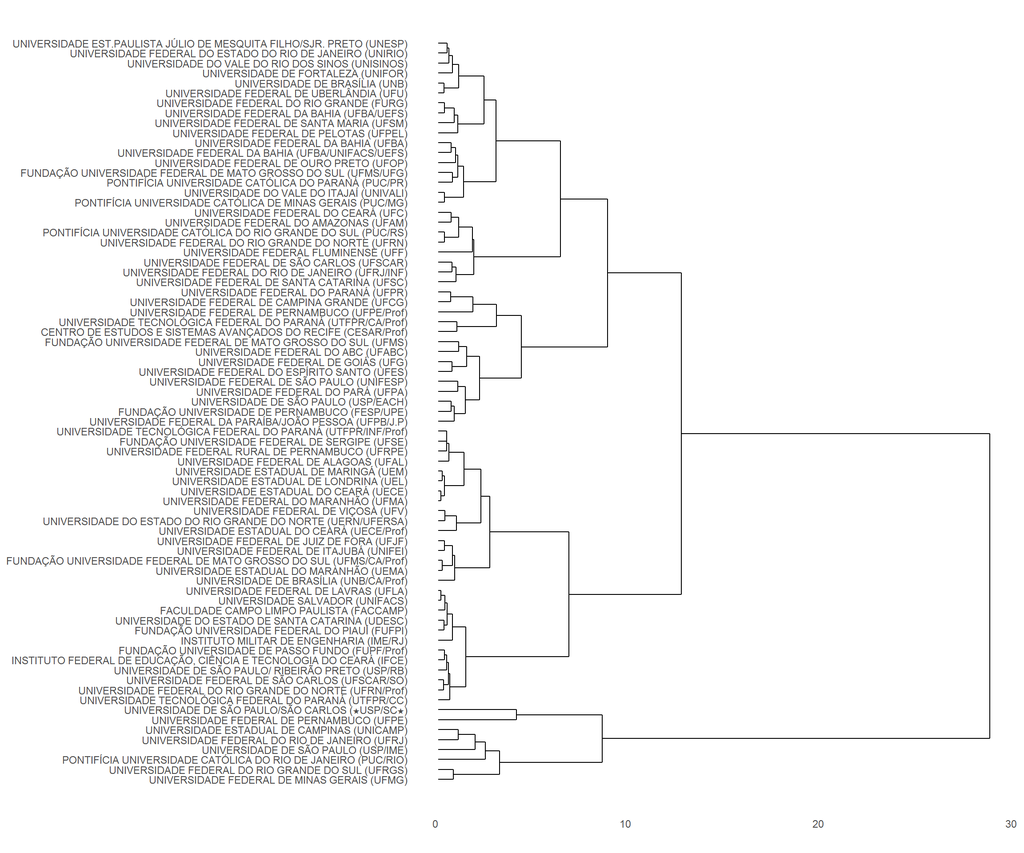

```r
clust_hier <- distancias %>%
  hclust(method = "ward.D")

ggdendrogram(clust_hier, rotate = TRUE)
```

O dendograma acima mostra a árvore de agrupamento realizada pelo algoritmo de clusterização hierárquica. Visualmente, eu acredito que 3 ou 4 grupos formariam uma boa clusterização. Além disso, também quero destacar alguns pontos interessantes:

- **As melhores universidades brasileiras se encontram na parte de baixo do dendograma**;
- **A UFPB foi agrupada com a USP/EACH e FESP/UPE**;
- **A UFCG foi agrupada com a UFPR**;

Vamos agora plotar o gráfico de silhueta. Eu testei o gráfico para 3 e 4 grupos. Acabei escolhendo 4 grupos, pois achei a quantidade de pontos em cada grupo mais homogênea em relação a somente 3 grupos.

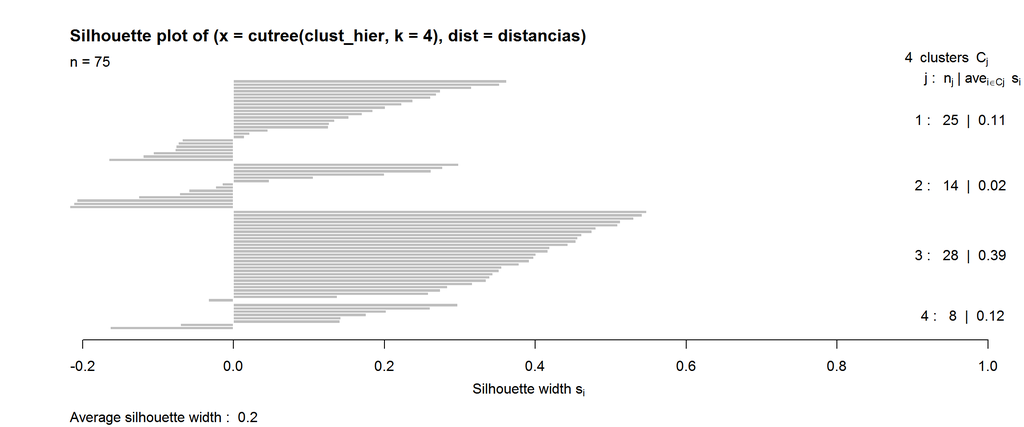

```r
plot(silhouette(cutree(clust_hier, k = 4), distancias))
```

Pode-se perceber pelo gráfico acima que os 4 grupos possuem entre 8 e 28 universidades. Ademais, a maior parte dos pontos estão bem alocados em seus grupos. O *Grupo 3* é o grupo com o melhor alocamento de pontos, enquanto o *Grupo 2* apresenta a maior dúvida sobre a alocação de alguns de seus pontos.

Tendo em vista que clusterizamos as universidades em 4 grupos pelo algoritmo de clusterização hierárquica, vamos agora analisar as características de cada um dos grupos e distingui-los:

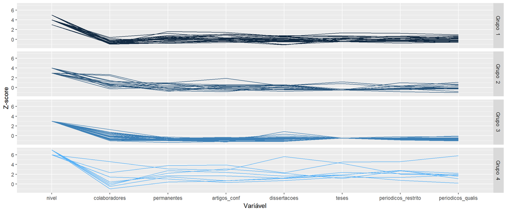

```r
atribuicoes <- cbind(dados_pro, grupo = cutree(clust_hier, k = 4))

atribuicoes %>%
  select(-instituicao) %>%
  ggparcoord(columns = c(1:8), groupColumn="grupo", scale = "globalminmax") +
  facet_grid(paste("Grupo ", grupo) ~ .) +
  theme(legend.position = "none") +
  scale_y_continuous(breaks=c(0, 2, 4, 6)) +
  labs(x = "Variável", y = "Z-score")
```

De acordo com o gráfico acima, eu nomearia os grupos da seguinte maneira (fazendo analogia ao campeonato brasileiro):

**Grupo 1**: *Série B* (Universidades que brigam para subir)  
Universidades de nível 3-5, poucos colaboradores e o restante das variáveis na média geral;

**Grupo 2**: *Série C* (Universidades que querem se tornar “profissionais”)  
Universidades de nível 3-4, com mais colaboradores que as do *Grupo 1*, porém almejam o Doutorado (Série B) em sua maioria.

**Grupo 3**: *Série D* (Várzea)  
Universidades de nível 3, sem Doutorado, e com a maioria das variáveis abaixo da média.

**Grupo 4**: *Série A* (Universidades supra-sumo)  
Universidades de nível 6-7, com alto nível de produção científica em geral.

Vamos agora visualizar alguns integrantes desses grupos:

```r
dados_hclust <- atribuicoes %>%
  left_join(dados, by = c("instituicao")) %>%
  select(instituicao, nivel.y, colaboradores.y, permanentes.y, artigos_conf.y, dissertacoes.y, teses.y, periodicos_qualis.y, periodicos_restrito.y,  grupo)

dados_hclust %>%
  filter(grupo == 1) %>%
  head(10) %>%
  kable()
```

| instituicao | nivel.y | colaboradores.y | permanentes.y | artigos_conf.y | dissertacoes.y | teses.y | periodicos_qualis.y | periodicos_restrito.y | grupo |
| --- | --- | --- | --- | --- | --- | --- | --- | --- | --- |
| UNIVERSIDADE FEDERAL DO AMAZONAS (UFAM) | 5 | 0.25 | 24.75 | 390 | 108 | 14 | 33 | 53 | 1 |
| UNIVERSIDADE FEDERAL DO CEARÁ (UFC) | 5 | 2.00 | 20.75 | 269 | 75 | 24 | 46 | 79 | 1 |
| UNIVERSIDADE DE FORTALEZA (UNIFOR) | 4 | 1.00 | 16.00 | 179 | 60 | 5 | 59 | 50 | 1 |
| UNIVERSIDADE FEDERAL DO RIO GRANDE DO NORTE (UFRN) | 5 | 2.25 | 26.25 | 389 | 108 | 29 | 53 | 99 | 1 |
| UNIVERSIDADE FEDERAL DA BAHIA (UFBA/UNIFACS/UEFS) | 4 | 3.00 | 19.00 | 277 | 0 | 20 | 34 | 50 | 1 |
| UNIVERSIDADE FEDERAL DA BAHIA (UFBA/UEFS) | 3 | 0.50 | 23.25 | 255 | 41 | 0 | 30 | 45 | 1 |
| UNIVERSIDADE FEDERAL DA BAHIA (UFBA) | 4 | 3.75 | 22.00 | 230 | 8 | 0 | 30 | 51 | 1 |
| UNIVERSIDADE FEDERAL DO RIO DE JANEIRO (UFRJ/INF) | 4 | 2.75 | 28.25 | 288 | 101 | 16 | 75 | 101 | 1 |
| UNIVERSIDADE FEDERAL FLUMINENSE (UFF) | 5 | 0.00 | 40.00 | 504 | 110 | 56 | 79 | 138 | 1 |
| UNIVERSIDADE FEDERAL DO ESTADO DO RIO DE JANEIRO (UNIRIO) | 4 | 0.50 | 17.50 | 268 | 89 | 0 | 32 | 27 | 1 |

```r
dados_hclust %>%
  filter(grupo == 2) %>%
  head(10) %>%
  kable()
```

| instituicao | nivel.y | colaboradores.y | permanentes.y | artigos_conf.y | dissertacoes.y | teses.y | periodicos_qualis.y | periodicos_restrito.y | grupo |
| --- | --- | --- | --- | --- | --- | --- | --- | --- | --- |
| UNIVERSIDADE FEDERAL DO PARÁ (UFPA) | 4 | 5.50 | 14.00 | 284 | 77 | 0 | 86 | 78 | 2 |
| UNIVERSIDADE FEDERAL DA PARAÍBA/JOÃO PESSOA (UFPB/J.P) | 3 | 5.00 | 20.00 | 322 | 108 | 0 | 42 | 52 | 2 |
| UNIVERSIDADE FEDERAL DE CAMPINA GRANDE (UFCG) | 4 | 9.25 | 31.00 | 338 | 104 | 40 | 56 | 64 | 2 |
| UNIVERSIDADE FEDERAL DE PERNAMBUCO (UFPE/Prof) | 3 | 8.50 | 32.00 | 585 | 92 | 0 | 69 | 122 | 2 |
| FUNDAÇÃO UNIVERSIDADE DE PERNAMBUCO (FESP/UPE) | 3 | 6.50 | 10.75 | 255 | 71 | 0 | 33 | 29 | 2 |
| CENTRO DE ESTUDOS E SISTEMAS AVANÇADOS DO RECIFE (CESAR/Prof) | 3 | 13.75 | 12.50 | 79 | 93 | 0 | 1 | 2 | 2 |
| UNIVERSIDADE FEDERAL DO ESPÍRITO SANTO (UFES) | 4 | 6.00 | 22.25 | 336 | 110 | 5 | 11 | 43 | 2 |
| UNIVERSIDADE DE SÃO PAULO (USP/EACH) | 3 | 6.25 | 14.25 | 227 | 56 | 0 | 59 | 36 | 2 |
| UNIVERSIDADE FEDERAL DE SÃO PAULO (UNIFESP) | 3 | 3.00 | 21.00 | 167 | 24 | 0 | 67 | 75 | 2 |
| UNIVERSIDADE FEDERAL DO ABC (UFABC) | 3 | 7.25 | 29.75 | 156 | 60 | 0 | 37 | 49 | 2 |

```r
dados_hclust %>%
  filter(grupo == 3) %>%
  head(10) %>%
  kable()
```

| instituicao | nivel.y | colaboradores.y | permanentes.y | artigos_conf.y | dissertacoes.y | teses.y | periodicos_qualis.y | periodicos_restrito.y | grupo |
| --- | --- | --- | --- | --- | --- | --- | --- | --- | --- |
| UNIVERSIDADE FEDERAL DO MARANHÃO (UFMA) | 3 | 3.00 | 10.00 | 115 | 50 | 0 | 19 | 23 | 3 |
| UNIVERSIDADE ESTADUAL DO MARANHÃO (UEMA) | 3 | 6.25 | 14.00 | 73 | 25 | 0 | 18 | 5 | 3 |
| FUNDAÇÃO UNIVERSIDADE FEDERAL DO PIAUÍ (FUFPI) | 3 | 1.75 | 9.50 | 150 | 31 | 0 | 24 | 17 | 3 |
| UNIVERSIDADE ESTADUAL DO CEARÁ (UECE/Prof) | 3 | 6.25 | 15.75 | 0 | 129 | 0 | 7 | 2 | 3 |
| UNIVERSIDADE ESTADUAL DO CEARÁ (UECE) | 3 | 2.75 | 8.50 | 120 | 45 | 0 | 17 | 18 | 3 |
| INSTITUTO FEDERAL DE EDUCAÇÃO, CIÊNCIA E TECNOLOGIA DO CEARÁ (IFCE) | 3 | 0.75 | 9.00 | 92 | 3 | 0 | 20 | 14 | 3 |
| UNIVERSIDADE FEDERAL DO RIO GRANDE DO NORTE (UFRN/Prof) | 3 | 2.00 | 8.50 | 60 | 12 | 0 | 4 | 6 | 3 |
| UNIVERSIDADE DO ESTADO DO RIO GRANDE DO NORTE (UERN/UFERSA) | 3 | 4.25 | 13.50 | 127 | 94 | 0 | 12 | 14 | 3 |
| UNIVERSIDADE FEDERAL RURAL DE PERNAMBUCO (UFRPE) | 3 | 3.50 | 14.00 | 132 | 26 | 0 | 42 | 32 | 3 |
| UNIVERSIDADE FEDERAL DE ALAGOAS (UFAL) | 3 | 5.75 | 14.00 | 185 | 23 | 0 | 34 | 48 | 3 |

```r
dados_hclust %>%
  filter(grupo == 4) %>%
  head(10) %>%
  kable()
```

| instituicao | nivel.y | colaboradores.y | permanentes.y | artigos_conf.y | dissertacoes.y | teses.y | periodicos_qualis.y | periodicos_restrito.y | grupo |
| --- | --- | --- | --- | --- | --- | --- | --- | --- | --- |
| UNIVERSIDADE FEDERAL DE PERNAMBUCO (UFPE) | 6 | 22.25 | 58.50 | 763 | 433 | 144 | 113 | 187 | 4 |
| UNIVERSIDADE FEDERAL DO RIO DE JANEIRO (UFRJ) | 7 | 2.00 | 38.75 | 359 | 154 | 87 | 122 | 194 | 4 |
| PONTIFÍCIA UNIVERSIDADE CATÓLICA DO RIO DE JANEIRO (PUC/RIO) | 7 | 0.00 | 25.25 | 367 | 146 | 68 | 50 | 106 | 4 |
| UNIVERSIDADE FEDERAL DE MINAS GERAIS (UFMG) | 7 | 4.25 | 47.50 | 809 | 213 | 49 | 105 | 231 | 4 |
| UNIVERSIDADE DE SÃO PAULO (USP/IME) | 6 | 9.75 | 32.75 | 296 | 120 | 57 | 116 | 144 | 4 |
| UNIVERSIDADE DE SÃO PAULO/SÃO CARLOS (USP/SC) | 6 | 13.25 | 67.25 | 959 | 220 | 152 | 274 | 355 | 4 |
| UNIVERSIDADE ESTADUAL DE CAMPINAS (UNICAMP) | 7 | 5.50 | 41.50 | 546 | 151 | 73 | 131 | 235 | 4 |
| UNIVERSIDADE FEDERAL DO RIO GRANDE DO SUL (UFRGS) | 7 | 3.00 | 54.25 | 680 | 177 | 73 | 86 | 238 | 4 |

É interessante notar que a UFPB e UFCG estão situadas no *Grupo 2*.

## 2.2 K-Means

Agora vou utilizar o K-means para clusterização. Vou começar analisando o valor de *tot.withinss* para o K-means aplicado de 2 a 12 grupos. O valor de *tot.withinss* representa o somatório dos quadrados das distâncias de cada ponto em cluster $c_i$ para o centro do seu cluster. Esse valor tende a zero quando o número de clusters é igual ao número de pontos.

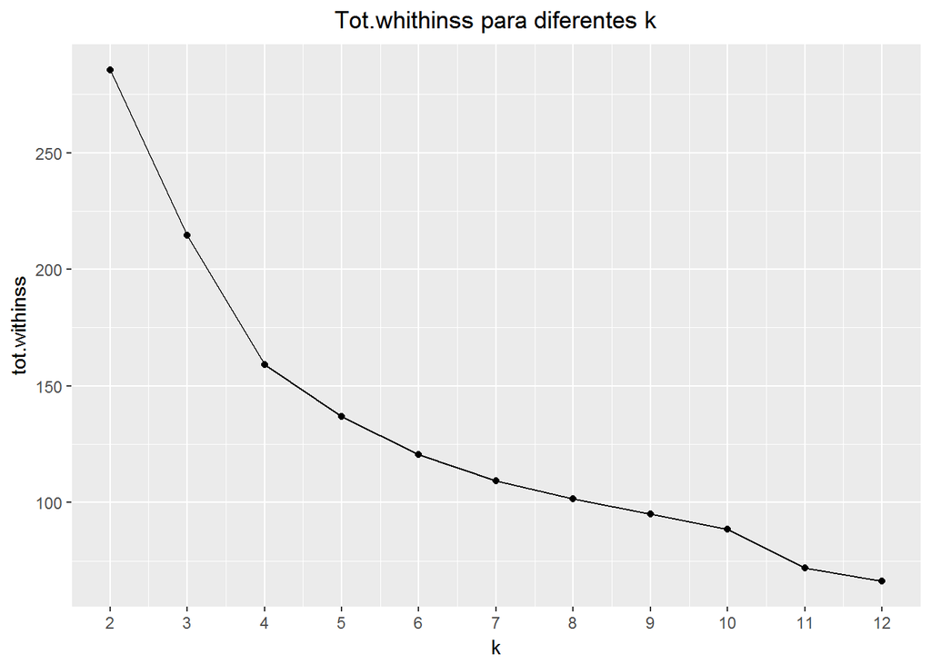

```r
set.seed(1234)
explorando_k <- tibble(k = 2:12) %>%
  group_by(k) %>%
  do(
    kmeans(select(dados_pro, -instituicao), centers = .$k, nstart = 20) %>% glance()
  )

explorando_k %>%
  ggplot(aes(x = k, y = tot.withinss)) +
  geom_line() +
  geom_point() +
  scale_x_continuous(breaks=c(2:12)) +
  ggtitle("Tot.whithinss para diferentes k")
```

Pelo gráfico, podemos ver que o valor de *tot.withinss* descresce bastante de 2 para 3 clusters e de 3 para 4 clusters. De 4 clusters em diante, esse valor descrece pouco. Logo, por esse grafico, podemos definir 4 clusters como a quantidade de clusters “ideal”.

Podemos também analisar também a proporção entre as distâncias dos centróides dos clusters em relação ao centróide de todos os pontos, e a distância de todos os pontos para o centróide dos pontos:

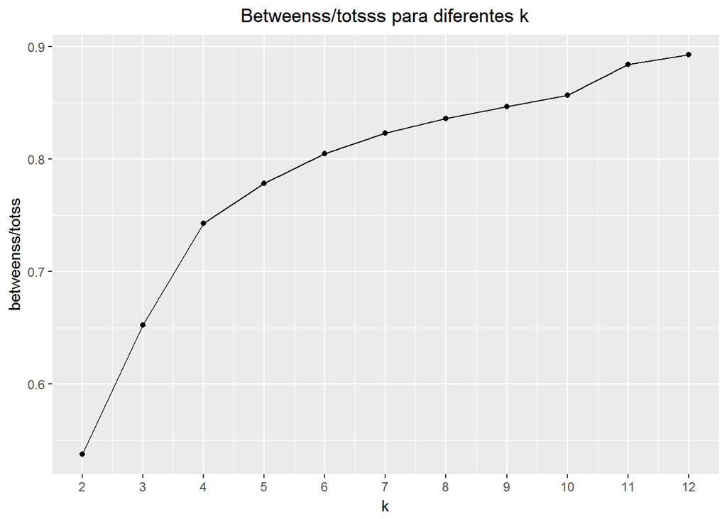

```r
explorando_k %>%
  ggplot(aes(x = k, y = betweenss/totss)) +
  geom_line() +
  geom_point() +
  scale_x_continuous(breaks = c(2:12)) +
  ggtitle("Betweenss/totsss para diferentes k")
```

Esse gráfico apresenta um comportamente parecido com o anterior. Novamente, a escolha de 4 clusters é a mais sensata.

Visto que 4 clusters representam a melhor escolha para o número de clusters de acordo com os gráficos, vamos analisar a representação desses grupos:

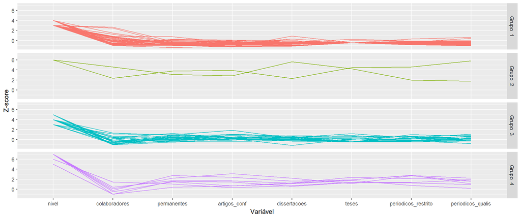

```r
set.seed(1234)
km <- dados_pro %>%
  select(-instituicao) %>%
  kmeans(centers = 4, nstart = 20)

km %>%
  augment(dados_pro) %>%
  select(-instituicao) %>%
  ggparcoord(columns = c(1:8), groupColumn = ".cluster", scale = "globalminmax") +
  facet_grid(paste("Grupo ", .cluster) ~ .) +
  theme(legend.position = "none") +
  scale_y_continuous(breaks = c(0, 2, 4, 6)) +
  labs(x = "Variável", y = "Z-score")
```

Seguindo a mesma ideia dos grupos da clusterização hierárquica, eu nomearia os grupos da seguinte forma:

**Grupo 1**: *Série D* (Várzea)  
Universidades de nível 3 e 4, sem Doutorado ou pouco produtivo, e com a maioria das variáveis abaixo da média de maneira geral.

**Grupo 2**: *Fora do padrão* (Universidades modelo)  
Universidades de nível 6, com todas as variáveis bem acima da média. Altíssimo nível de produção científica.

**Grupo 3**: *Série B*  
Universidades de nível 3-5, e acima da média de maneira geral.

**Grupo 4**: *Série A*  
Universidades de nível 5-7, poucos colabores em sua maioria, mas com nível de produção científica acima da média

Ao meu ver, os grupos 1, 3 e 4 são bastante parecidos com os grupos equivalentes da clusterização hierárquica.

Assim como na seção anterior, vamos analisar as universidades participantes de cada grupo:

```r
dados_km <- km %>%
  augment(dados)

dados_km %>%
  filter(.cluster == 1) %>%
  head(10) %>%
  kable()
```

| instituicao | nivel | colaboradores | permanentes | artigos_conf | dissertacoes | teses | periodicos_restrito | periodicos_qualis | .cluster |
| --- | --- | --- | --- | --- | --- | --- | --- | --- | --- |
| UNIVERSIDADE FEDERAL DO MARANHÃO (UFMA) | 3 | 3.00 | 10.00 | 115 | 50 | 0 | 23 | 19 | 1 |
| UNIVERSIDADE ESTADUAL DO MARANHÃO (UEMA) | 3 | 6.25 | 14.00 | 73 | 25 | 0 | 5 | 18 | 1 |
| FUNDAÇÃO UNIVERSIDADE FEDERAL DO PIAUÍ (FUFPI) | 3 | 1.75 | 9.50 | 150 | 31 | 0 | 17 | 24 | 1 |
| UNIVERSIDADE ESTADUAL DO CEARÁ (UECE/Prof) | 3 | 6.25 | 15.75 | 0 | 129 | 0 | 2 | 7 | 1 |
| UNIVERSIDADE ESTADUAL DO CEARÁ (UECE) | 3 | 2.75 | 8.50 | 120 | 45 | 0 | 18 | 17 | 1 |
| INSTITUTO FEDERAL DE EDUCAÇÃO, CIÊNCIA E TECNOLOGIA DO CEARÁ (IFCE) | 3 | 0.75 | 9.00 | 92 | 3 | 0 | 14 | 20 | 1 |
| UNIVERSIDADE FEDERAL DO RIO GRANDE DO NORTE (UFRN/Prof) | 3 | 2.00 | 8.50 | 60 | 12 | 0 | 6 | 4 | 1 |
| UNIVERSIDADE DO ESTADO DO RIO GRANDE DO NORTE (UERN/UFERSA) | 3 | 4.25 | 13.50 | 127 | 94 | 0 | 14 | 12 | 1 |
| UNIVERSIDADE FEDERAL RURAL DE PERNAMBUCO (UFRPE) | 3 | 3.50 | 14.00 | 132 | 26 | 0 | 32 | 42 | 1 |
| FUNDAÇÃO UNIVERSIDADE DE PERNAMBUCO (FESP/UPE) | 3 | 6.50 | 10.75 | 255 | 71 | 0 | 29 | 33 | 1 |

```r
dados_km %>%
  filter(.cluster == 2) %>%
  head() %>%
  kable()
```

| instituicao | nivel | colaboradores | permanentes | artigos_conf | dissertacoes | teses | periodicos_restrito | periodicos_qualis | .cluster |
| --- | --- | --- | --- | --- | --- | --- | --- | --- | --- |
| UNIVERSIDADE FEDERAL DE PERNAMBUCO (UFPE) | 6 | 22.25 | 58.50 | 763 | 433 | 144 | 187 | 113 | 2 |
| UNIVERSIDADE DE SÃO PAULO/SÃO CARLOS (USP/SC) | 6 | 13.25 | 67.25 | 959 | 220 | 152 | 355 | 274 | 2 |

```r
dados_km %>%
  filter(.cluster == 3) %>%
  head(10) %>%
  kable()
```

| instituicao | nivel | colaboradores | permanentes | artigos_conf | dissertacoes | teses | periodicos_restrito | periodicos_qualis | .cluster |
| --- | --- | --- | --- | --- | --- | --- | --- | --- | --- |
| UNIVERSIDADE FEDERAL DO AMAZONAS (UFAM) | 5 | 0.25 | 24.75 | 390 | 108 | 14 | 53 | 33 | 3 |
| UNIVERSIDADE FEDERAL DO PARÁ (UFPA) | 4 | 5.50 | 14.00 | 284 | 77 | 0 | 78 | 86 | 3 |
| UNIVERSIDADE FEDERAL DO CEARÁ (UFC) | 5 | 2.00 | 20.75 | 269 | 75 | 24 | 79 | 46 | 3 |
| UNIVERSIDADE DE FORTALEZA (UNIFOR) | 4 | 1.00 | 16.00 | 179 | 60 | 5 | 50 | 59 | 3 |
| UNIVERSIDADE FEDERAL DO RIO GRANDE DO NORTE (UFRN) | 5 | 2.25 | 26.25 | 389 | 108 | 29 | 99 | 53 | 3 |
| UNIVERSIDADE FEDERAL DA PARAÍBA/JOÃO PESSOA (UFPB/J.P) | 3 | 5.00 | 20.00 | 322 | 108 | 0 | 52 | 42 | 3 |
| UNIVERSIDADE FEDERAL DE CAMPINA GRANDE (UFCG) | 4 | 9.25 | 31.00 | 338 | 104 | 40 | 64 | 56 | 3 |
| UNIVERSIDADE FEDERAL DE PERNAMBUCO (UFPE/Prof) | 3 | 8.50 | 32.00 | 585 | 92 | 0 | 122 | 69 | 3 |
| UNIVERSIDADE FEDERAL DA BAHIA (UFBA/UNIFACS/UEFS) | 4 | 3.00 | 19.00 | 277 | 0 | 20 | 50 | 34 | 3 |
| UNIVERSIDADE FEDERAL DO ESPÍRITO SANTO (UFES) | 4 | 6.00 | 22.25 | 336 | 110 | 5 | 43 | 11 | 3 |

```r
dados_km %>%
  filter(.cluster == 4) %>%
  head(7) %>%
  kable()
```

| instituicao | nivel | colaboradores | permanentes | artigos_conf | dissertacoes | teses | periodicos_restrito | periodicos_qualis | .cluster |
| --- | --- | --- | --- | --- | --- | --- | --- | --- | --- |
| UNIVERSIDADE FEDERAL DO RIO DE JANEIRO (UFRJ) | 7 | 2.00 | 38.75 | 359 | 154 | 87 | 194 | 122 | 4 |
| UNIVERSIDADE FEDERAL FLUMINENSE (UFF) | 5 | 0.00 | 40.00 | 504 | 110 | 56 | 138 | 79 | 4 |
| PONTIFÍCIA UNIVERSIDADE CATÓLICA DO RIO DE JANEIRO (PUC/RIO) | 7 | 0.00 | 25.25 | 367 | 146 | 68 | 106 | 50 | 4 |
| UNIVERSIDADE FEDERAL DE MINAS GERAIS (UFMG) | 7 | 4.25 | 47.50 | 809 | 213 | 49 | 231 | 105 | 4 |
| UNIVERSIDADE DE SÃO PAULO (USP/IME) | 6 | 9.75 | 32.75 | 296 | 120 | 57 | 144 | 116 | 4 |
| UNIVERSIDADE ESTADUAL DE CAMPINAS (UNICAMP) | 7 | 5.50 | 41.50 | 546 | 151 | 73 | 235 | 131 | 4 |
| UNIVERSIDADE FEDERAL DO RIO GRANDE DO SUL (UFRGS) | 7 | 3.00 | 54.25 | 680 | 177 | 73 | 238 | 86 | 4 |

Interessante notar as universidades do *Grupo 2*, mesmo não sendo nível 7, elas se destacam como as universidades com alto padrão de produção científica. A UFPB e UFCG, agora, aparecem na *Série B*.

Na próxima seção, vamos reduzir as 8 dimensões que temos para apenas 2 - utilizando PCA e t-SNE - e visualizar os resultados do clusterização pelo K-means.

# 3. Redução da Dimensionalidade

## 3.1 Principal Component Analysis (PCA)

Primeiramente, vamos utilizar o PCA. Vamos começar analisando os componentes principais e variância explicada pelos componentes:

```r
dados_pca <- dados_pro %>%
  select(-instituicao) %>%
  prcomp(scale = FALSE)

as.data.frame(dados_pca$rotation)  %>% kable()
```

|  | PC1 | PC2 | PC3 | PC4 | PC5 | PC6 | PC7 | PC8 |
| --- | --- | --- | --- | --- | --- | --- | --- | --- |
| nivel | -0.3987424 | -0.3955536 | 0.5203570 | -0.3810568 | 0.4513960 | -0.0615673 | 0.1493588 | -0.1967467 |
| colaboradores | -0.1695414 | 0.8750861 | 0.0166215 | -0.2867285 | 0.3487760 | 0.0063283 | -0.0175826 | -0.0315674 |
| permanentes | -0.3771071 | 0.0189993 | -0.1327842 | 0.3423898 | 0.0503691 | 0.7527040 | 0.3706388 | -0.1268593 |
| artigos_conf | -0.3700856 | -0.0504548 | -0.1891649 | 0.5057392 | 0.3219814 | -0.2247050 | -0.5870156 | -0.2649222 |
| dissertacoes | -0.3444813 | 0.2317941 | 0.4977165 | 0.4396016 | -0.3755981 | -0.3750970 | 0.2789382 | 0.1644830 |
| teses | -0.3724407 | 0.0277997 | 0.1331482 | -0.3641500 | -0.5959815 | 0.2810060 | -0.5173223 | -0.0916559 |
| periodicos_restrito | -0.3847241 | -0.1335100 | -0.2695043 | -0.1122760 | 0.1434749 | -0.0267338 | -0.0511991 | 0.8514710 |
| periodicos_qualis | -0.3573444 | -0.0502861 | -0.5809084 | -0.2472224 | -0.2270132 | -0.3984180 | 0.3838908 | -0.3369848 |

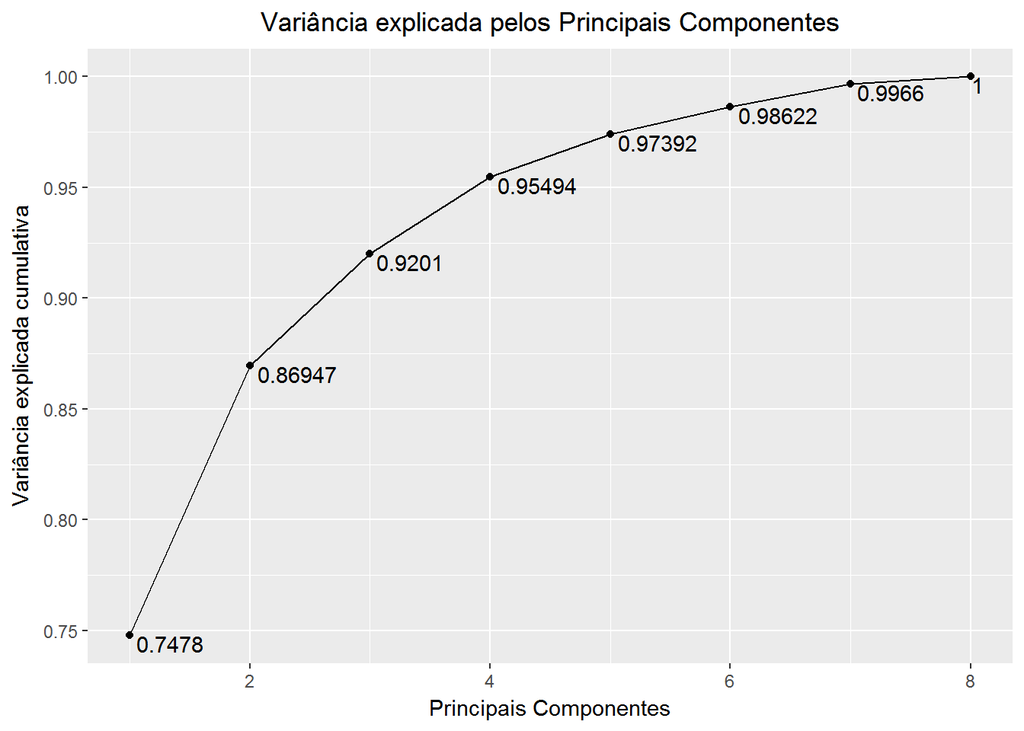

```r
tidy(dados_pca, "pcs") %>%
  ggplot(aes(x = PC, y = cumulative, label = cumulative)) +
  geom_line() +
  geom_point() +
  geom_text(vjust = 1, hjust = -.1) +
  ggtitle("Variância explicada pelos Principais Componentes") +
  labs(x = "Principais Componentes", y = "Variância explicada cumulativa")
```

Pelo gráfico, podemos ver que **o primeiro autovetor (PC1) contém aproximadamente 74,78% de toda informação. Os dois primeiros autovetores, que iremos utilizar no restante dessa análise, por sua vez, armazenama aproximadamente 87% de toda informação**.

O próximo grafo projeta os nossos dados (8-dimensional) nos dois primeiros autovetores:

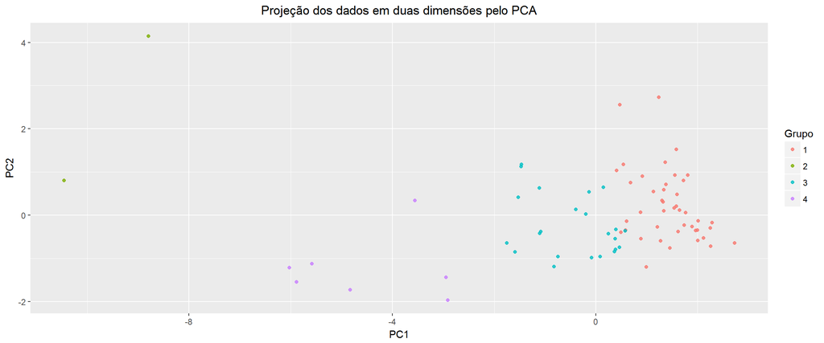

```r
dados_pro_aug <- km %>% augment(dados)

dados_pca %>%
  augment(dados_pro_aug) %>%
  ggplot(aes(x = .fittedPC1, y = .fittedPC2, color = .cluster)) +
  geom_point(alpha = 0.8) +
  labs(color = "Grupo") +
  ggtitle("Projeção dos dados em duas dimensões pelo PCA") +
  labs(x = "PC1", y = "PC2")
```

É possivel observar que, ao menos nesses dois componentes, nossos dados aparentam realmente ter 4 grupos. É importante destacar as duas universidades do *Grupo 2*, que estão significantemente afastadas dos demais grupos (canto superior-meio-esquerdo).

Vamos visualizar o mesmo grafo de forma interativa:

```r
p = dados_pca %>%
  augment(dados_pro_aug) %>%
  hchart("scatter", hcaes(x = .fittedPC1, y = .fittedPC2, color = .cluster)) %>%
  hc_tooltip(pointFormat = "<b>{point.instituicao}</b><br>
                     Nível: {point.nivel}<br>
             Colaboradores: {point.colaboradores}<br>
               Permanentes: {point.permanentes}<br>
             Artigos Conf.: {point.artigos_conf}<br>
              Dissertações: {point.dissertacoes}<br>
                     Teses: {point.teses}<br>
                Per. A1-B1: {point.periodicos_restrito}<br>
                Per. B2-B5: {point.periodicos_qualis}")
p
```

[interactive chart not shown]

Por fim, vamos plotar os vetores de nossas variáveis sobre os componentes principais:

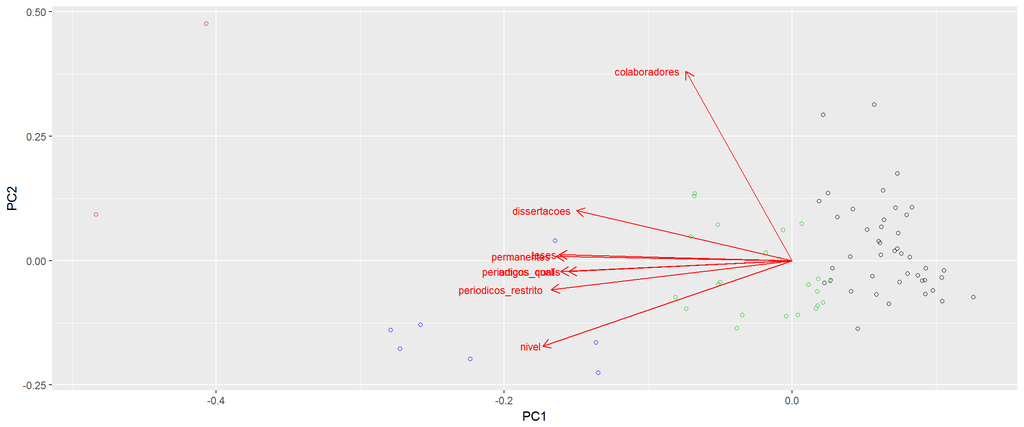

```r
autoplot(dados_pca, label = F, label.size = 3, shape = T, colour = km$cluster, loadings = TRUE, loadings.color = 'red', loadings.label = TRUE, loadings.label.size = 3, loadings.label.hjust=1.1)
```

## 3.2 t-SNE

Nesta última seção, vamos reduzir a dimensionalidade utilizando o algoritmo conhecido como t-SNE e comparar os resultados obtido com o PCA.

Reduzindo a dimensionalidade dos nossos dados com o t-SNE, temos:

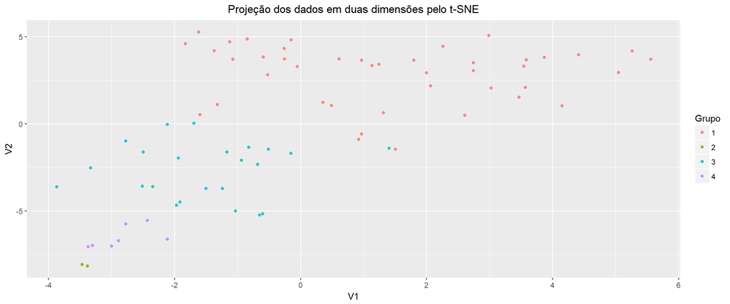

```r
set.seed(1234)
tsne.out = dados_pro %>%
  select(-instituicao) %>%
  Rtsne(perplexity = 20)

df <- as.data.frame(tsne.out$Y)
dados_tsne <- cbind(dados_pro_aug, df)

dados_tsne %>%
  ggplot(aes(x = V1, y = V2, color = .cluster)) +
  geom_point(alpha = 0.8) +
  labs(color = "Grupo") +
  ggtitle("Projeção dos dados em duas dimensões pelo t-SNE")
```

Podemos observar que as universidades do *Grupo 2* se situam bem mais próximos dos demais grupos agora que em relação aos resultado obtido com o PCA. Interessante notar que onde $V1 > 0$ e $V2 > 0$, praticamente só há pontos do *Grupo 1*. Comportamento, este, bem diferente do resultado do PCA.

Por fim, o mesmo gráfico de forma interativa:

```r
p <- dados_tsne %>%
  hchart("scatter", hcaes(x = V1, y = V2, color = .cluster)) %>%
  hc_tooltip(pointFormat = "<b>{point.instituicao}</b><br>
                     Nível: {point.nivel}<br>
             Colaboradores: {point.colaboradores}<br>
               Permanentes: {point.permanentes}<br>
             Artigos Conf.: {point.artigos_conf}<br>
              Dissertações: {point.dissertacoes}<br>
                     Teses: {point.teses}<br>
                Per. A1-B1: {point.periodicos_restrito}<br>
                Per. B2-B5: {point.periodicos_qualis}")

p
```

[interactive chart not shown]